# Projekt zaliczeniowy - Metody analizy danych finansowych/Wprowadzenie do R i Python

Zuzanna Czerny (177406), Anna Tomas (178391), Marta Witkowska (178470)

# Cel przeprowadzenia badania

Przeprowadzone badanie miało na celu dokonanie oceny rynku nieruchmości w ośmiu wybranych krajach Europy na przestrzeni ostatnich 10 lat. Wyniki są wypadkową poziomu standardu mieszkaniowego, dostępności mieszkaniowej oraz sytuacji gospodarczej badanych krajów. Pokazują w którym z wybranych krajów sytuacja mieszkaniowa powinna ulec poprawie.

# Założenia

Badaniu poddano grupę ośmiu krajów, do której należą: Węgry, Polska, Słowacja, Czechy, Francja, Holandia, Dania i Norwegia. Zebrano wartości zmiennych w dwuletnich odstępach czasowych, zatem dla roku 2012, 2014, 2016, 2018 i 2020. Jako wartość progową współczynnika zmienności przyjęto 10%. Natomiast w przypadku korelacji założono, że wartość powyżej której zmienne są eliminowane to 0,81.

# Dobór zmiennych

Wybrane cechy opisują sytuację ekonomiczno – gospodarczą oraz rynki nieruchomości w wybranych krajach. Zmienne prezentują w szczególności jak kształtuje się standard mieszkaniowy oraz warunki życia osób zamieszkujących nieruchomości mieszkaniowe w analizowanych krajach od 2012 roku. W Tabeli 1 zaprezentowano wybrane potencjalne zmienne oraz ich charakter. Wybrane cechy mogą przyjmować charakter stymulanty, gdy wzrastające wartości danej zmiennej są zjawiskiem pożądanym. Odwrotnie zachowują się destymulanty – rosnące wartości świadczą o spadku poziomu danego zjawiska. Z kolei dla nominant wyznacza się przedziały wartości pożądanych, a wszelkie odchylenia od wyznaczonego przedziału są uważane za niewskazane

**Tabela 1: Potencjalne zmienne i ich charakter**

|  | Nazwa potencjalnej zmiennej | Charakter |
| --- | --- | --- |
| X1 | PKB per capita | Stymulanta |
| X2 | Zmiana liczby ludności | Stymulanta |
| X3 | Odsetek społeczeństwa posiadający mieszkania własnościowe | Stymulanta |
| X4 | Wskaźnik ceny zakupu mieszkania do dochodu rozporządzalnego przypadającego na 1 osobę | Destymulanta |
| X5 | Wskaźnik ceny zakupu mieszkania do opłat wymagalnych z tytułu najmu | Stymulanta |
| X6 | Wskaźnik przeludnienia | Destymulanta |
| X7 | Wskaźnik przeciążenia kosztami związanymi z utrzymaniem nieruchomości mieszkaniowej | Destymulanta |
| X8 | Przeciętna liczba pomieszczeń przypadająca na 1 osobę | Stymulanta |
| X9 | Odsetek populacji nie posiadający dostępu do wanny, prysznica, ani spłukiwanej toalety w obrębie zamieszkiwanej nieruchomości mieszkaniowej | Destymulanta |
| X10 | Odsetek populacji zamieszkujący nieruchomość mieszkaniową o przeciekającym dachu, zawilgoconych ścianach, podłogach, fundamentach oraz zgniłych podłogach i ramach okiennych | Destymulanta |

Wartości przedstawionych potencjalnych cech diagnostycznych zostały pozyskane z Eurostatu (X1, X2, X3, X6, X7, X8, X9, X10) i OECD (X4, X5).

# Metodologia

W celu scharakteryzowania zjawiska, na które wpływa wiele zmiennych wybrana została metoda sum standaryzowanych. Jest jedną z metod porządkowania liniowego, należących do licznych podejść wielowymiarowej analizy porównawczej. Istnieje również wiele innych sposobów na obliczenie syntetycznego wskaźnika odzwierciedlającego poziom zjawiska złożonego - np. taksonomiczna miara rozwoju Hellwiga. Przed zastosowaniem wybranej metody dokonano dyskryminacji zmiennych, dobranych uprzednio na podstawie kryterium merytorycznego.

Pierwszym krokiem było obliczenie średniej, odchylenia standarowego oraz współczynnika zmienności w poszczególnych latach dla wybranych zmiennych.Do eliminacji potencjalnych zmiennych w pierwszej kolejności zastosowano kryterium współczynnika zmienności. Zgodnie z założeniami zmienne, których współczynnik zmienności był niższy niż przyjęta wartość zostały na tym etapie wykluczone.

Następnie dla pozostałych zmiennych wyznaczono macierz korelacji. Zmienne, których zależności z innymi były bardzo silne oraz wyraźnie odstawały od poziomu korelacji pozostałych cech powinny zostały wyeliminowane. Wysoka zależność między zmiennymi świadczy o powielaniu przez nie identycznych informacji.

Zastosowana metoda wymaga dokonania standaryzacji, aby zmienne stały się porównywalne. Standaryzację przeprowadza się dzieląc różnicę wartości i – tego obiektu danej zmiennej i jej średniej przez jej odchylenie standardowe, zgodnie z poniższym wzorem.

$$z_{ij}=\frac{x_{ij} - \overline{x}_{j}}{s_{i}}$$

gdzie:

$x_{ij}$ - wartość i - tego obiektu j - tej zmiennej,

$\overline{x}_{j}$ - średnia j - tej zmiennej

$s_{i}$ - odchylenie standardowe j - tej zmiennej.

Metoda zakłada również, iż wszystkie zmienne muszą mieć charakter stymulanty. Należy zatem dokonać zamiany destymulant i nominant. W przypadku destymulant uprzednio wystandaryzowane wartości powinny zostać pomnożone przez (-1). Jeśli zmienne mają charakter nominant, należy postępować zgodnie z poniższym wzorem:

$$z_{i j}=\left\{\begin{array}{c}
1, \text { dla } x_{i j}=N_{j} \\
\frac{-1}{x_{i j}-N_{j}-1}, \text { dla } x_{i
j}<N_{j},(\mathrm{i}=1,2, \ldots, \mathrm{n}) \\
\frac{1}{x_{i j}-N_{j}+1}, \text { dla } x_{i
j}>\mathrm{N}_{\mathrm{j}}
\end{array}\right.$$
gdzie:

$N_{ij}$ - wartość nominalna j – tej zmiennej (nominanty),

${x}_{ij}$ - i – ty obiekt j – tej zmiennej (nominanty),

$z_{ij}$ – i – ty obiekt j – tej zmiennej po dokonaniu zamiany nominanty w stymulantę.

Na tak przygotowanym zbiorze zmiennych można zastosować metodę sum standaryzowanych. W pierwszym kroku metody należy obliczyć sumę zmiennych dla każdego obiektu, zgodnie z wzorem:

$$p_{i}=\sum_{j=1}^{m} z_{i j} \mid$$

Następnie dla każdego z obiektów oblicza się tzw. miarę rozwoju, w oparciu o wzór :

$$m_{i}=\frac{p_{i} - {x}_{p-o}}{p_{0}-{p_{-0}}}$$
gdzie:

- $$p_{0}=\sum_{j=1}^{m} z_{0 j}
  \mid$$
- $$p_{-0}=\sum_{j=1}^{m} z_{-0 j}
  \mid$$

a wartości ${z}_{0j}$ i ${z}_{-0j}$ są wartościami zmiennych dla obiektów abstrakcyjnych, stosownie wzorca oraz antywzorca, wyznaczonych tak jak następuje:

- $$z_{0 j}=\max _{i} z_{i
  j}$$
- $$z_{-0 j}=\min _{i} z_{i
  j}$$

Ze względu na to, iż wszystkie zmienne mają charakter stymulant, już po obliczeniu sumy zmiennych dla każdego obiektu w pierwszym kroku możliwe jest ich uporządkowanie od najlepszego do najgorszego. Wyznaczenie miar rozwoju w drugim kroku tej metody pozwala dodatkowo na unormowanie tych wartości tak, że mieszczą się w przedziale [0;1], w tym miara dla wzorca wynosi 1, a dla antywzorca 0.

# Obliczenia w R

Pierwszym krokiem w celu dokonania obliczeń było załadowanie potrzebnych pakietów:

```r
library(caret)
library(stats)
library(utils)
```

Następnie w środowisku R zdefiniowano funkcję *obliczWspółczynniki*, za pomoca której obliczano kolejne kroki opisane w teoretycznym opisie metody. Było to zatem obliczenie średniej (*colMeans*), odchylenia standardowego (*sapply*) i współćzynnika zmienności, a następnie odrzucenie zmiennych o współczynniku zmienności mniejszym niż 10%. Następnie użyto funkcji *findCorrelation* z pakietu *caret*, aby dokonać eliminacji wysoko skorelowanych zmiennych. Kolejno zestandaryzowano pozostałe w modelu zmienne (*scale*). Następnie stworzono kilka pętli, których zadaniem było stworzenie wektora, za pomocą którego dokonano zamiany destymulant w stymulanty, w zależności od tego, które ze zmiennych wyeliminowano ze względu na wysoki współczynnnik korelacji. W ostatnim kroku obliczono miarę rozwoju, której zwracanie ma za zadanie zdefiniowana funkcja.

```r
obliczWspolczynniki <- function(daneZPliku){

srednia <- colMeans(daneZPliku)
odch.stand. <- sapply(daneZPliku,sd)
vs<-odch.stand./srednia

daneZPliku<-subset(daneZPliku,,vs>0.1)

korelacja<-cor(daneZPliku,method="pearson")
dyskryminacja_korelacja<-findCorrelation(korelacja,cutoff=0.81,exact=TRUE)
dyskryminacja_korelacja<-sort(dyskryminacja_korelacja)
macierz_zredukowana<-daneZPliku[-c(dyskryminacja_korelacja)]

macierz_standaryzowana<-scale(macierz_zredukowana,center=TRUE,scale=TRUE)
macierz_standaryzowana<-as.data.frame(macierz_standaryzowana)

d<-c()
if ((is.null(macierz_standaryzowana$x1))==FALSE){
d<-append(d,1)
}
if ((is.null(macierz_standaryzowana$x2))==FALSE){
d<-append(d,1)
}
if ((is.null(macierz_standaryzowana$x3))==FALSE){
d<-append(d,1)
}
if ((is.null(macierz_standaryzowana$x4))==FALSE){
d<-append(d,-1)
}
if ((is.null(macierz_standaryzowana$x5))==FALSE){
d<-append(d,1)
}
if ((is.null(macierz_standaryzowana$x6))==FALSE){
d<-append(d,-1)
}
if ((is.null(macierz_standaryzowana$x7))==FALSE){
d<-append(d,-1)
}
if ((is.null(macierz_standaryzowana$x8))==FALSE){
d<-append(d,1)
}
if ((is.null(macierz_standaryzowana$x9))==FALSE){
d<-append(d,-1)
}
if ((is.null(macierz_standaryzowana$x10))==FALSE){
d<-append(d,-1)
}
macierz_zamiana<-sweep(macierz_standaryzowana,2,d,'*')

x<-apply(macierz_zamiana,2,min)
y<-apply(macierz_zamiana,2,max)
z<-rowSums(macierz_zamiana,na.rm=FALSE)
x<-sum(x)
y<-sum(y)
mi<-(z-x)/(y-x)
miary_rozwoju<-data.frame(mi)
}
```

Pliki z danymi mają format *csv*. Należy więc ustalić domyślną ścieżkę do plików na urządzeniu użytkownika przy pomocy pokazującego się okna wyboru, aby program mógł załdować z danej lokalizacji pliki do obliczeń.

```r
workdir=choose.dir()
setwd(workdir)
path<-file.path(getwd())
sciezkiDoPliku <- list(plik1 ="2012.csv", plik2 = "2014.csv", plik3 = "2016.csv", plik4="2018.csv", plik5="2020.csv")
daneZRoku <- list()
df<-list.files(path,pattern=".csv")
```

Na końcu stworzoną funkcję przypisano do listy plików *danezRoku* i zapętlono, aby funkcja została zastosowana dla wszystkich 5 plików.

```r
for (i in 1:length(sciezkiDoPliku)) {
rok<-read.csv2(sciezkiDoPliku[[i]],header =TRUE,sep=";",,dec=",")
daneZRoku[[length(daneZRoku) + 1]] <- obliczWspolczynniki(rok)
}
```

# Wyniki badania

Zgodnie z opisaną metodologią, w pierwszym kroku dokonano eliminacji wybranych cech diagnostycznych ze względu na kryterium współczynnika zmienności. Jako wartość progową V* ustalono 10%. Dla każdego roku zmienne X4 oraz X5 przyjęły wartości poniżej V*, zatem zostały wykluczone z dalszych obliczeń.

Następnie zastosowano metodę sum standaryzowanych, uprzednio zamieniając zmienne o charakterze destymulant - X6, X7, X9 i X10 - w stymulanty. Kolejno wyznaczono wartość minimalną i maksymalną dla każdej zmiennej, obliczono wartość pi oraz za pomocą wzoru obliczono wartość miar rozwoju. Tabela 2 zawiera obliczone wartości miar rozwoju dla poszczególnych krajów w wyznaczonych latach, które pozwalają na uszeregowanie krajów od najsłabiej rozwiniętego pod względem sytuacji mieszkaniowej do najlepiej rozwiniętego.

**Tabela 2. Miary rozwoju dla poszczegolnych panstw**

|  | 2012 | 2014 | 2016 | 2018 | 2020 |
| --- | --- | --- | --- | --- | --- |
| Węgry | 0,2136 | 0,2249 | 0,3095 | 0,3067 | 0,4153 |
| Polska | 0,4681 | 0,4918 | 0,5407 | 0,4477 | 0,4529 |
| Słowacja | 0,7267 | 0,6758 | 0,7203 | 0,6615 | 0,6332 |
| Czechy | 0,6097 | 0,5959 | 0,6218 | 0,6327 | 0,6382 |
| Francja | 0,6210 | 0,6343 | 0,6244 | 0,6364 | 0,5051 |
| Holandia | 0,4648 | 0,4462 | 0,5352 | 0,6032 | 0,6145 |
| Dania | 0,4001 | 0,3867 | 0,3906 | 0,4408 | 0,4009 |
| Norwegia | 0,8764 | 0,9018 | 0,8509 | 0,8113 | 0,8122 |

W celu wizualizacji otrzymanych wyników stworzono poniższy wykres.

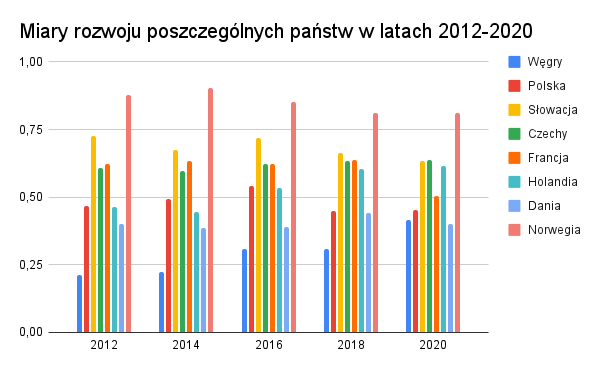

# Źródła

J. Dziechciarz, *Ekonometria. Metody, przykłady, zadania, Wydawnictwo Akademii Ekonomicznej im. Oskara Langego we Wrocławiu*, Wrocław 2003, s. 287 - 291

W. N. Venables, D. M. Smith and the R Core Team, *An Introduction to R*, s.26-27, 40, 48 https://cran.r-project.org/doc/manuals/r-release/R-intro.pdf?fbclid=IwAR2LyoWZFCQK-00k9ztgbDDtKuoW9ypVaNPEYm6k-5ZRQ102CTbfF2MyP38, (data dostępu: 13.05.2022)

https://stackoverflow.com/questions/22002838/same-function-over-multiple-data-frames-in-r (data dostępu: 13.05.2022)

https://stackoverflow.com/questions/39163671/applying-a-function-to-a-list-of-data-frames-in-r (data dostępu: 13.05.2022)

https://swcarpentry.github.io/r-novice-inflammation/02-func-R/ (data dostępu: 13.05.2022)

https://www.analyticsvidhya.com/blog/2021/01/correlation-analysis-using-r/ (data dostępu: 13.05.2022)

https://www.datasciencemadesimple.com/get-standard-deviation-of-a-column-in-r-2/ (data dostępu: 13.05.2022)

https://www.datamentor.io/r-programming/if-else-statement/ (data dostępu: 11.05.2022)

https://statisticsglobe.com/r-is-null-function/ (data dostępu: 11.05.2022)

https://www.geeksforgeeks.org/adding-elements-in-a-vector-in-r-programming-append-method/ (data dostępu: 11.05.2022)

https://www.datacamp.com/tutorial/tutorial-on-loops-in-r (data dostępu: 11.05.2022)